# Exploratory Analysis

## Cryptocurrency

Cryptocurrency is a decentralized, virtual medium of exchange that has become very popular over a rather short period of time. It relies on the participation of users in the blockchain network. These users, or rather their computers, solve complicated mathematical algorithms in order to validate blocks to acquire some share of a crypto coin. Due to the security provided by validating transactions and using a sequential blockchain, this quickly evolving type of currency could guide financial markets in the future. Originally cryptocurrency, namely Bitcoin, was heavily used in black market transactions due to the difficulty of tracing it back to an individual user. It is intriguing that it was started by computer scientists and was quickly manipulated by black market actors. There is also a huge influx of younger people between the ages of 16 and 25 that are investing their money in cryptocurrency. This has helped fuel Bitcoin and spark the creation of so many other cryptocurrencies. Recently the sharp rise in the price of Bitcoin has only furthered the intrigue surrounding crypto, however many still believe tt has not reached its full potential yet. Analyzing past trends and external factors may allow us to predict the behavior of crypto. Moreover, the price of cryptocurrencies is linked to the price of computer hardware such as graphical processing units so anlaysis may also help to deduce the impact of new hardware on the price of crypto.

## Summary of Data Sets

This report draws on six different data sets. Five of the data sets represent financial information and are thus similar in nature. The other data set consists of various information associated with different models of graphical processing units. To gain a better understanding and appreciation of each data set we found summary values that are of interest to us as creators. The data sets and their summary values are described below.

[**Bitcoin Prices (Yahoo Finance)**](https://raw.githubusercontent.com/cjrieth/AC-5GroupProject/main/data/BTC-USD-YAHOO.csv)

[**Bitcoin Prices (Kaggle)**](https://raw.githubusercontent.com/cjrieth/AC-5GroupProject/main/data/kaggle_crypto_data/bitcoin_price.csv)

This data set has 7 features with the following names: Date, Open, Price, Low, Close, Volume, Market.Cap. It also has 1760 individual observations. The data tells us that the price of Bitcoin started at $136.0 on April 28, 2013 and reached a maximum price of $20,089.0 on December 17, 2017.

[**Ethereum Prices**](https://raw.githubusercontent.com/cjrieth/AC-5GroupProject/main/data/kaggle_crypto_data/ethereum_price.csv)

This data set has 7 features with the following names: Date, Open, Price, Low, Close, Volume, Market.Cap. It also has 929 individual observations. The data tells us that the price of Ethereum started at $3.5 on August 07, 2015 and reached a maximum price of $1,432.9 on January 13, 2018.

[**Dash Prices**](https://raw.githubusercontent.com/cjrieth/AC-5GroupProject/main/data/kaggle_crypto_data/iota_price.csv)

This data set has 7 features with the following names: Date, Open, Price, Low, Close, Volume, Market.Cap. It also has 1468 individual observations. The data tells us that the price of Dash started at $0.4 on February 14, 2014 and reached a maximum price of $1,642.2 on December 20, 2017.

[**Iota Prices**](https://raw.githubusercontent.com/cjrieth/AC-5GroupProject/main/data/kaggle_crypto_data/iota_price.csv)

This data set has 7 features with the following names: Date, Open, Price, Low, Close, Volume, Market.Cap. It also has 253 individual observations. The data tells us that the price of Iota started at $0.7 on June 13, 2017 and reached a maximum price of $5.7 on December 19, 2017.

[**GPU Releases**](https://raw.githubusercontent.com/cjrieth/AC-5GroupProject/main/data/gpu-cpu-history-kaggle/All_GPUs.csv)

This data set contains information outside the scope of this report. It has 34 features and 3406 individual observations. Information we found pertinent is as follows. The highest price of a GPU unpon its release date was for the model Fermi GF100 (x2) , released at a price of $14,999.0 on July 25, 2011.

## Close Price of Bitcoin and New Releases of GPUs

The table below gives a record of the number of releases of new GPUs and the close price of Bitcoin at the date of each release.

| Date | Close Price | Number of GPUs Released |
| --- | --- | --- |
| 2016-03-01 | 435 | 7 |
| 2016-03-06 | 407 | 1 |
| 2016-03-09 | 414 | 1 |
| 2016-04-26 | 466 | 1 |
| 2016-05-13 | 455 | 3 |
| 2016-05-27 | 473 | 24 |
| 2016-06-01 | 536 | 7 |
| 2016-06-10 | 577 | 37 |
| 2016-06-27 | 655 | 4 |
| 2016-06-29 | 639 | 29 |
| 2016-07-01 | 676 | 1 |
| 2016-07-13 | 654 | 1 |
| 2016-07-19 | 672 | 27 |
| 2016-07-27 | 654 | 1 |
| 2016-07-28 | 655 | 4 |
| 2016-07-29 | 656 | 5 |
| 2016-08-01 | 606 | 2 |
| 2016-08-02 | 547 | 1 |
| 2016-08-04 | 578 | 19 |
| 2016-08-08 | 591 | 19 |
| 2016-08-15 | 567 | 2 |
| 2016-08-17 | 573 | 2 |
| 2016-08-18 | 574 | 21 |
| 2016-08-29 | 574 | 1 |
| 2016-08-30 | 577 | 2 |
| 2016-09-01 | 572 | 3 |
| 2016-10-18 | 637 | 15 |
| 2016-10-20 | 630 | 3 |
| 2016-10-25 | 657 | 5 |
| 2016-10-31 | 700 | 2 |
| 2016-11-01 | 729 | 15 |
| 2016-11-29 | 735 | 1 |
| 2017-01-01 | 998 | 1 |
| 2017-03-05 | 1267 | 41 |
| 2017-03-10 | 1116 | 5 |
| 2017-03-22 | 1049 | 1 |
| 2017-03-30 | 1026 | 1 |
| 2017-04-06 | 1182 | 1 |
| 2017-04-18 | 1211 | 100 |
| 2017-04-25 | 1265 | 1 |
| 2017-05-17 | 1839 | 1 |
| 2017-07-05 | 2601 | 1 |
| 2017-07-30 | 2757 | 2 |
| 2017-09-30 | 4338 | 1 |

## GPU Releases and Bitcoin Price

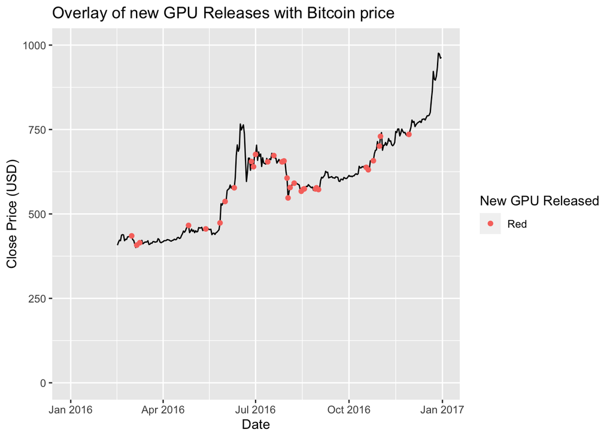

This chart is meant to explore how new releases of Graphical Processing Units, or GPUs, might affect the price of Bitcoin. Bitcoin is created by mining it with a computer, so the more computing power you have the more bitcoin you can gain. This means that Bitcoin miners are always quick to pick up the latest and greatest GPUs on the market, as they are more powerful than older versions and therefore better at mining crypto. There may be some correlation between the release of a new GPU and the price of Bitcoin upon its release.

## Bitcoin Trading and Days of the Week

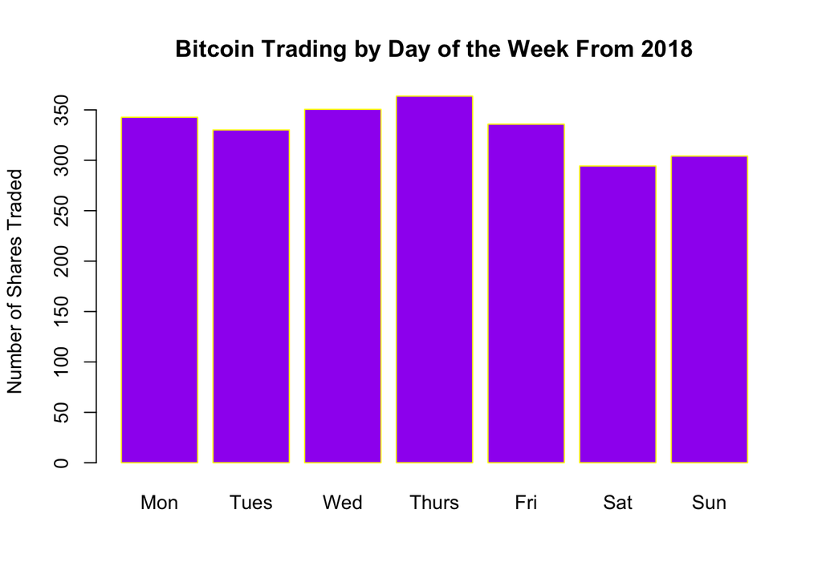

## Cryptocurrencies Prices in the Past Year

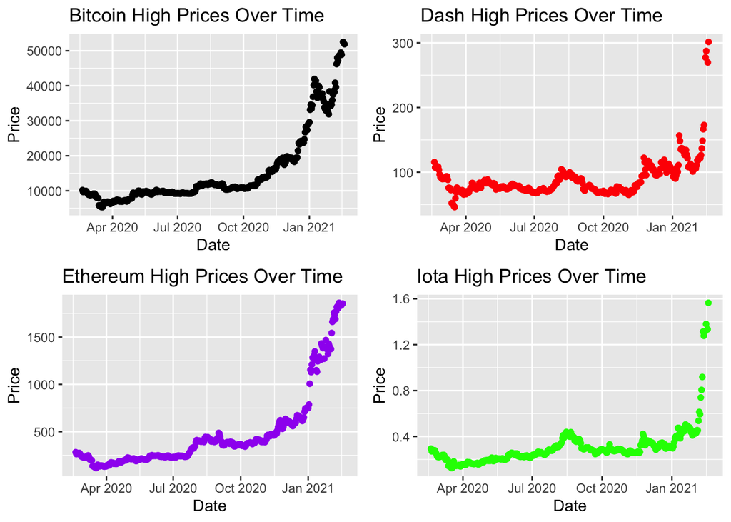

These graphs show the prices of Bitcoin, Dash, Ethereum, and Iota cryptocurrencies over this past year during the COVID Lockdown period. For all of these cryptocurrencies, the graphs show that the price has skyrocketed in these past few months as it is graphed for price versus time. The purpose of this chart is to show the trend of prices during COVID, it helps to understand the increase in popularity of mining and trading for cryptocurrencies.